# Final Report

Andrew Bernauer

April 30, 2019

# Difficult Learning Problems in Economics: Predicting Ether Price

# a) Introduction

For the semester long project I will be attempting to predict the known response variable ethereum price in terms of the predictors: block size, network hash rate growth rate, transactions, day of the week, and month. The project is regression based and not a classification task. Therefore the project will fall under the umbrella of supervised machine learning.

$$\text{ether price} \approx \beta_{o} + \beta_{1} \times \text{blocksize} + \beta_{2} \times \text{networkhashgrowthrate} + \beta_{3} \times \text{transactions} + \beta_{4} \times \text{day} + \beta_{5} \times \text{month}$$

Ethereum is a decentralized, open source, block chain technology, featuring smart contracts. The crypto currency that fuels the Ethereum block chain is Ether. Block size refers to the size of the Ethereum Block chain. Transactions are the number of transactions approved by the ledger. Hash rate is the rate at which it takes a miner to complete a Cryptographic computation on the block chain.

```r
library(scales)
library(ggplot2)
library(lubridate)
library(purrr)
library(dplyr)
library(readr)
library(tibble)
library(errorist)
library(broom)
library(caret)
library(tidyr)
library(randomForest)
library(gbm)
#substitute in the path on your machine to files
ethereum_transaction_history <- read_csv("C:\\Users\\andre\\Documents\\ECON_490_ML\\ML_report 1\\ethereum-historical-data\\EthereumTransactionHistory.csv")
ethereum_block_size <-read_csv("C:\\Users\\andre\\Documents\\ECON_490_ML\\ML_report 1\\ethereum-historical-data\\EthereumBlockSizeHistory.csv"
)
ethereum_network_hash_rate <- read_csv("C:\\Users\\andre\\Documents\\ECON_490_ML\\ML_report 1\\ethereum-historical-data\\EthereumNetworkHashRateGrowthRate.csv")
ether_price <- read_csv("C:\\Users\\andre\\Documents\\ECON_490_ML\\ML_report 1\\ethereum-historical-data\\EtherPriceHistory(USD).csv")
# creating variable for day
day_of_week <-
  lubridate::mdy(ether_price$`Date(UTC)`) %>%
  wday( ,label=TRUE)  %>%
  sort()

# creating variable for month
month_of_year <-
  lubridate::mdy(ether_price$`Date(UTC)`) %>%
  month( ,label=TRUE) %>%
  sort()

signedlog10 <- function(x) {
  ifelse(abs(x) <= 1, 0, sign(x)*log10(abs(x)))
}

log_price <- signedlog10(ether_price[[3]])

log_history <- signedlog10(ethereum_transaction_history[[3]])

log_block_size <- signedlog10(ethereum_block_size[[3]])

log_hash_rate <- signedlog10(ethereum_network_hash_rate[[3]])

summary(log_price)
```

```
##    Min. 1st Qu.  Median    Mean 3rd Qu.    Max.
##  0.0000  0.9801  1.2708  1.5985  2.5227  3.1415
```

```r
summary(log_history)
```

```
##    Min. 1st Qu.  Median    Mean 3rd Qu.    Max.
##   0.000   4.570   4.803   4.967   5.732   6.130
```

```r
# construct list of variables to coerce into a tibble
l_ether <- list( price = ether_price[[3]],
                 transaction_history = as.integer(ethereum_transaction_history[[3]]),
                 block_size = as.integer(ethereum_block_size[[3]]),
                 hash_rate = ethereum_network_hash_rate[[3]],
                 day = day_of_week,
                 month = month_of_year,
                 date_utc = mdy(ethereum_network_hash_rate$`Date(UTC)`),
                 unix_time_stamp = ethereum_network_hash_rate$UnixTimeStamp,
                 log_10_price = log_price,
                 log_10_trans_history = log_history,
                 log_10_block_size = log_block_size,
                 log_10_hash_rate = log_hash_rate)

ether_df <- as_tibble(l_ether)


xs <-function(x){(x-mean(x))/(2*sd(x))}
```

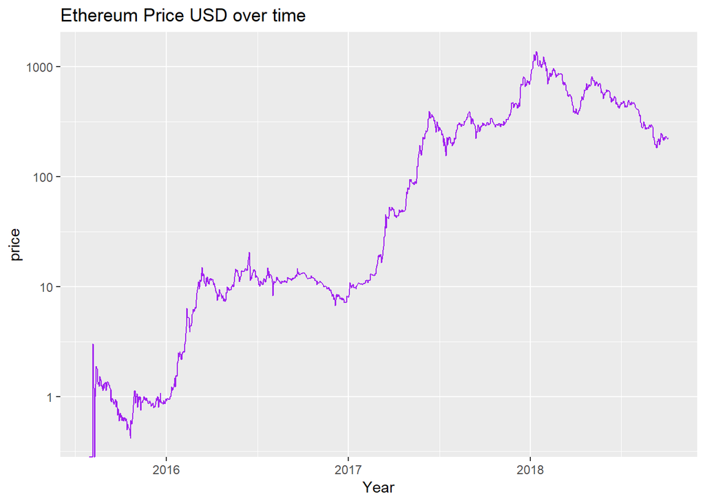

```r
price_history <- ggplot(ether_df) +
  aes(date_utc, price) +
  geom_line(color="purple") +
  xlab("Year")+
  ggtitle("Ethereum Price USD over time") +
  scale_y_log10()




 price_history
```

The price doesn’t seem move at all significantly until 2016 so I decided to use a log transformation to the y axis. This removed a large amount the visual noise and made the price change overtime more evident. Besides that ethereum price starts to rise from around a dollar price to hovering around the ten dollars between 2016 and 2017. Peaks at a value of 1000 dollars in 2018.

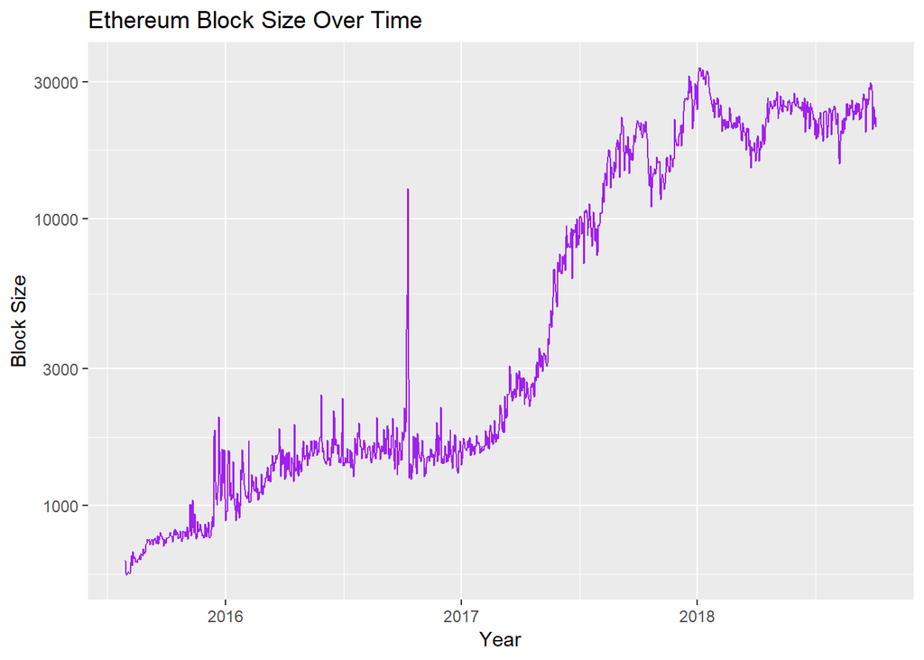

```r
block_history <- ggplot(ether_df) +
  aes(date_utc, block_size) +
  geom_line(color ="purple") +
  scale_y_log10() +
  xlab("Year") +
  ylab("Block Size") +
  ggtitle("Ethereum Block Size Over Time")


block_history
```

Block size rises exponentially begining in 2017. Prior to this it fluctuates up and down between 1000 and 3000 which might be pointing to autocorrelation. In this same time period it peaks violently at 10000. Reaching a maximum of over 30000 in 2018. Another log tranformation was used in this plot.

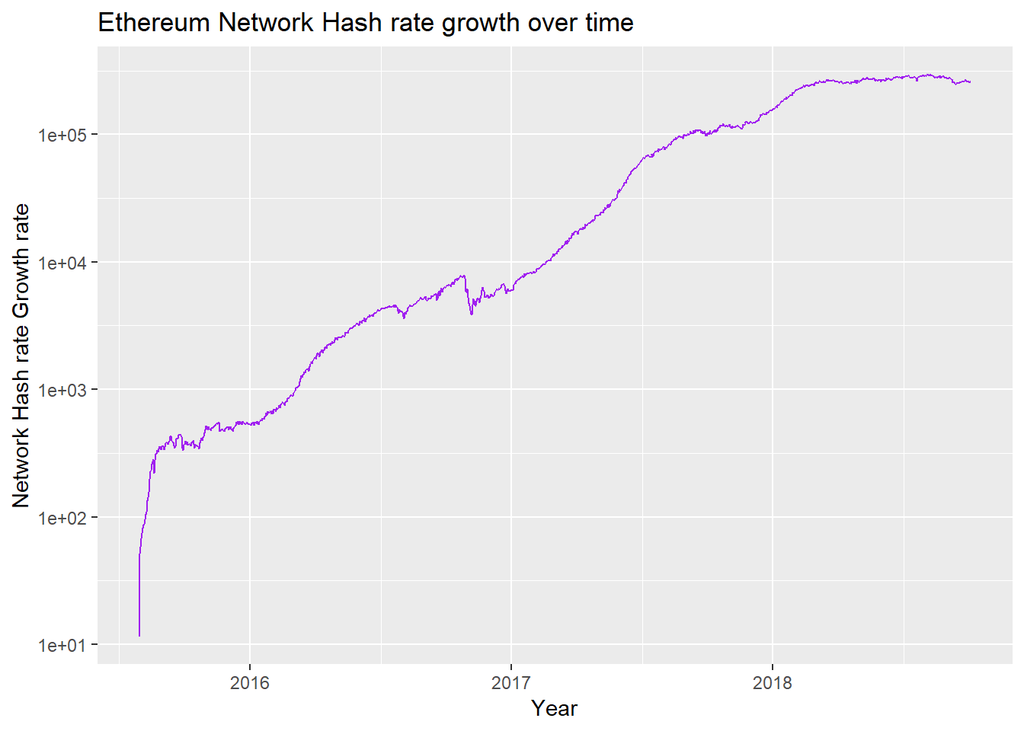

```r
 hashrate_history <- ggplot(ether_df) +
  aes(date_utc, hash_rate) +
  geom_line(color="purple") +
  scale_y_log10() +
  xlab("Year") +
  ylab("Network Hash rate Growth rate") +
  ggtitle("Ethereum Network Hash rate growth over time")

 hashrate_history
```

Network hashrate growth blows up exponentially and seems to follow that trend overtime.

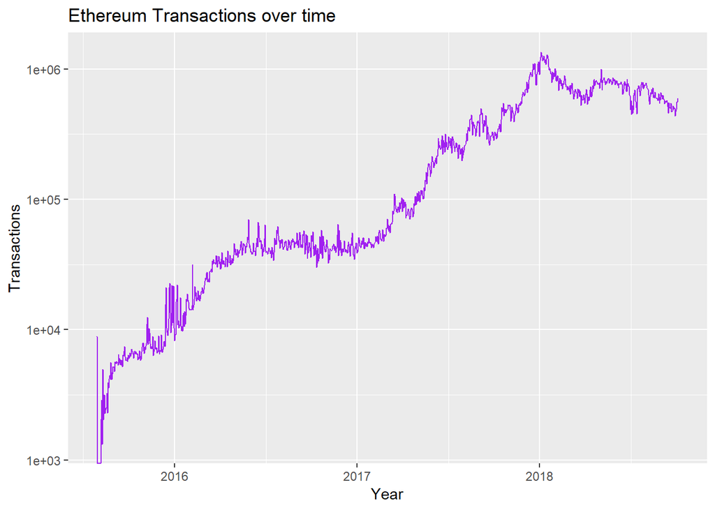

```r
 transaction_history <- ggplot(ether_df) +
  aes(date_utc, transaction_history) +
  geom_line(color="purple") +
  xlab("Year") +
  ylab("Transactions") +
  scale_y_log10() +
  ggtitle("Ethereum Transactions over time")

 transaction_history
```

Transactions on the the Ethereum network are growing significantly overtime and more people are embracing it’s use.

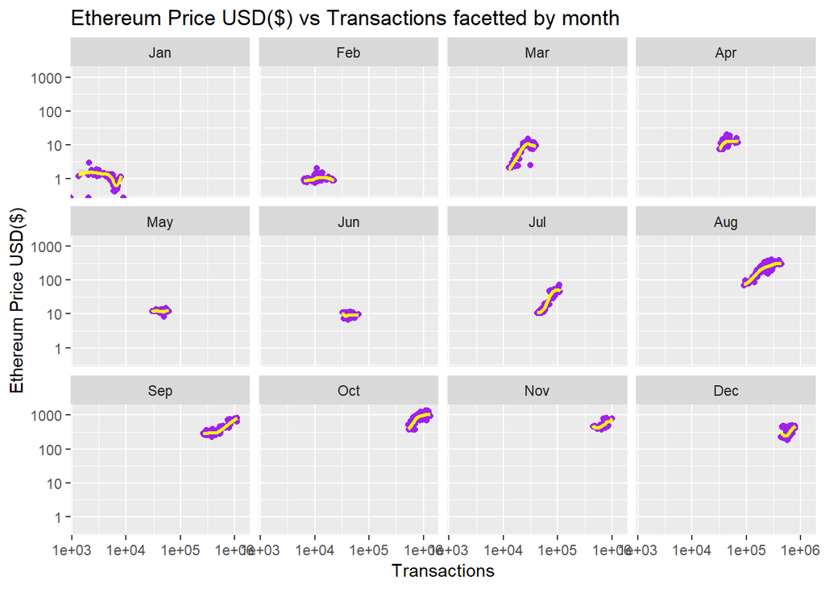

```r
 price_plot <- ggplot(ether_df) +
   aes(transaction_history, price) +
   geom_point(colour="purple") +
   facet_wrap(~month) +
   geom_smooth(colour="yellow", alpha = 0.25)

 price_plot +
   scale_x_log10("Transactions") +
   scale_y_log10("Ethereum Price USD($)") +
   ggtitle("Ethereum Price USD($) vs Transactions facetted by month")
```

There appears to be some clustering of Ether price as transactions increases on the block chain increase isolating by month.

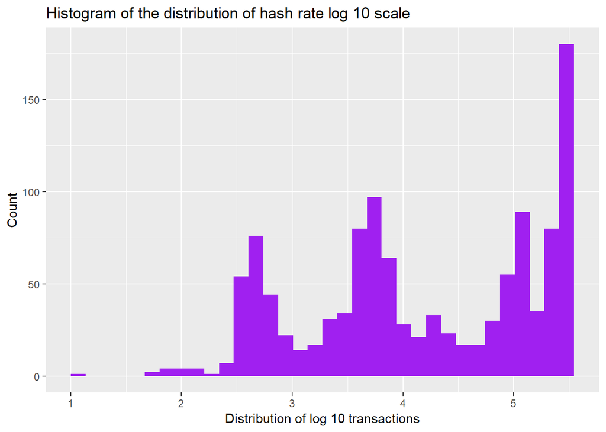

```r
library(ggplot2)
p <- ggplot(ether_df) +
  aes(x=log_10_hash_rate) +
  geom_histogram(bins = 34, fill = "purple") +
  ggtitle(label = "Histogram of the distribution of hash rate log 10 scale") +
  xlab("Distribution of log 10 transactions") +
  ylab("Count")


p
```

Many of the $X_{1}, X_{2}, \dots, X_{n}$ or predictor variables in the dataset follow skewed distribution and feature multiple peaks. This could be pointing to the presence of sub-populations within the underlying data.

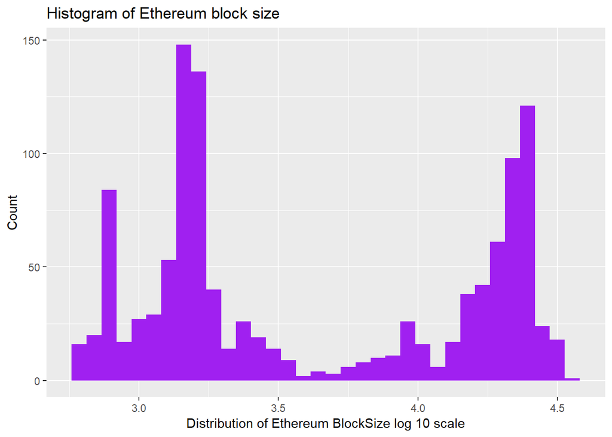

```r
ggplot(ether_df) +
  aes(log_block_size) + geom_histogram(bins = 34, fill = 'purple') +
  xlab("Distribution of Ethereum BlockSize log 10 scale") +
  ylab("Count") +
  ggtitle("Histogram of Ethereum block size")
```

Likewise, blocksize has this similar property this sort of distribution doesn’t suit itself well, for standard machine learning algorithms given the multiple peaks. Most of the variables follow gamma distributions in the cartesian coordinate scale. I declined to illustrate those graphs.

# b.) Summary Statistics

```r
#summary stats for ethereum price
ether_df %>% summarise(mean_price = mean(price, na.rm = TRUE), median_price = median(price), sd_price = sd(price), iqr_price = IQR(price), n = n(), mad_price = mad(price), min_price = min(price), max_price = max(price))
```

```
## # A tibble: 1 x 8
##   mean_price median_price sd_price iqr_price     n mad_price min_price
##        <dbl>        <dbl>    <dbl>     <dbl> <int>     <dbl>     <dbl>
## 1       212.         18.7     282.      324.  1164      26.9         0
## # ... with 1 more variable: max_price <dbl>
```

```r
#summary stats for ethereum transaction history
ether_df %>% summarise(mean_transaction_history = mean(transaction_history), median_transaction_history = median(transaction_history), sd_transaction_history = sd(transaction_history), iqr_transaction_history = IQR(transaction_history), n = n(), mad_transaction_history = mad(transaction_history), min_transaction_history = min(transaction_history), max_transaction_history = max(transaction_history))
```

```
## # A tibble: 1 x 8
##   mean_transactio~ median_transact~ sd_transaction_~ iqr_transaction~     n
##              <dbl>            <dbl>            <dbl>            <dbl> <int>
## 1          275451.           63518.          318759.          501880.  1164
## # ... with 3 more variables: mad_transaction_history <dbl>,
## #   min_transaction_history <dbl>, max_transaction_history <dbl>
```

```r
#summary stats for ethereum block size
ether_df %>% summarise(mean_block_size = mean(block_size), median_block_size = median(block_size), sd_block_size = sd(block_size), iqr_block_size = IQR(block_size), n = n(), mad_block_size = mad(block_size), min_block_size = min(block_size), max_block_size = max(block_size))
```

```
## # A tibble: 1 x 8
##   mean_block_size median_block_si~ sd_block_size iqr_block_size     n
##             <dbl>            <dbl>         <dbl>          <dbl> <int>
## 1           9292.             2209         9856.          18172  1164
## # ... with 3 more variables: mad_block_size <dbl>, min_block_size <dbl>,
## #   max_block_size <dbl>
```

```r
#summary stats for hash rate
ether_df %>% summarise(mean_hash_rate = mean(hash_rate), median_hash_rate = median(hash_rate), sd_hash_rate= sd(hash_rate), iqr_hash_rate = IQR(hash_rate), n = n(), mad_hash_rate = mad(hash_rate), min_hash_rate = min(hash_rate), max_hash_rate = max(hash_rate))
```

```
## # A tibble: 1 x 8
##   mean_hash_rate median_hash_rate sd_hash_rate iqr_hash_rate     n
##            <dbl>            <dbl>        <dbl>         <dbl> <int>
## 1         82768.           11610.      105868.       140979.  1164
## # ... with 3 more variables: mad_hash_rate <dbl>, min_hash_rate <dbl>,
## #   max_hash_rate <dbl>
```

# c) Linear Regressions

```r
#running five regressions

poly_reg <- lm(price ~ poly(transaction_history, 5) + poly(block_size, 5) + poly(hash_rate, 5), ether_df )


reg_obj <- lm(log(price) ~ log(block_size) + log(transaction_history) + log(hash_rate), data = ether_df,  subset = price > 0)

reg_obj_2 <- lm(log(price) ~ log(transaction_history) + log(hash_rate), data = ether_df, subset = price > 0)


reg_obj_3 <- lm(price ~ I(block_size)^2 + sqrt(transaction_history) + hash_rate, data = ether_df)

mols <- lm(price ~ block_size + transaction_history + hash_rate, data = ether_df)

log_ols <- lm(log(price) ~ log(transaction_history), data = ether_df, subset = price > 0)
```

The following code block returns the adjusted $\hat{R}^{2}_{\text{adjusted}}$ statistics for the five regressions I ran.

```r
tidy_reg_obj <- reg_obj %>%
   tidy()

tidy_reg_obj
```

```
## # A tibble: 4 x 5
##   term                     estimate std.error statistic   p.value
##   <chr>                       <dbl>     <dbl>     <dbl>     <dbl>
## 1 (Intercept)              -10.6       0.211     -50.4  8.64e-294
## 2 log(block_size)            0.0720    0.0387      1.86 6.32e-  2
## 3 log(transaction_history)   1.01      0.0491     20.5  5.66e- 80
## 4 log(hash_rate)             0.222     0.0311      7.15 1.56e- 12
```

```r
glance_tidy_poly <- glance(poly_reg)

glance_reg_obj <- glance(reg_obj)

glance_reg_obj_2 <- glance(reg_obj_2)

glance_reg_obj_3 <- glance(reg_obj_3)

glance_mols <- glance(mols)

glance_log_ols <- glance(log_ols)


glance_tidy_poly$adj.r.squared
```

```
## [1] 0.9396409
```

```r
glance_reg_obj$adj.r.squared
```

```
## [1] 0.9638884
```

```r
glance_reg_obj_2$adj.r.squared
```

```
## [1] 0.9638114
```

```r
glance_reg_obj_3$adj.r.squared
```

```
## [1] 0.8428993
```

```r
glance_mols$adj.r.squared
```

```
## [1] 0.9012137
```

```r
glance_log_ols$adj.r.squared
```

```
## [1] 0.9620687
```

Predictors performing the best presented the following equation
$$\hat{y} = -10.65 + 0.072 \log(\text{Blocksize}) + 1.0007 \log(\text{TransactionHistory}) + 0.222\log(\text{Hashrate})$$
.

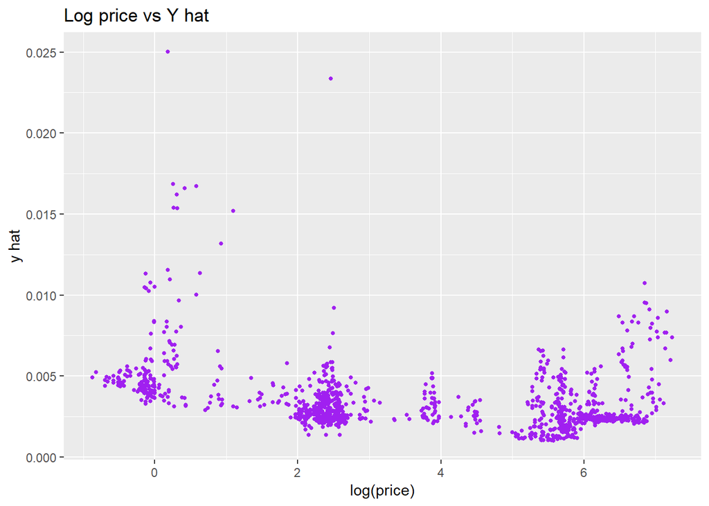

```r
augmented_reg_obj <- reg_obj %>%
             augment()

some_plot <- ggplot(data = augmented_reg_obj, aes(log.price., .hat)) +
  geom_point(color = "purple", size = 1) +
  labs(x="log(price)", y="y hat") +
  ggtitle("Log price vs Y hat")



some_plot
```

The preceding plot points to the non-linear nature of the data set. It may improve modeling results to include a polynomial term in future models.

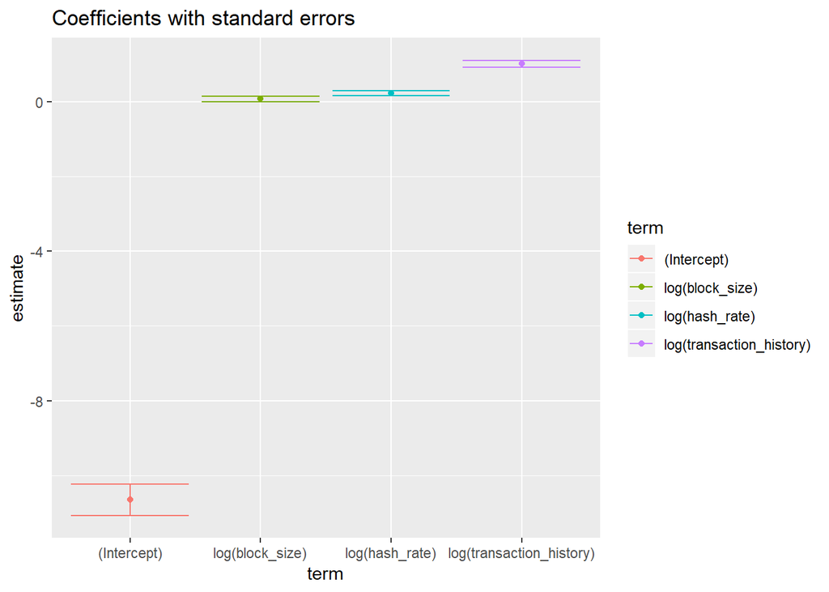

```r
tidy_conf_it <- tidy(reg_obj, conf.int = TRUE)

confint_plot <- ggplot(tidy_conf_it, aes(term, estimate, color=term)) +
  geom_point() +
  geom_errorbar(aes(ymin=estimate - 1.96*std.error, ymax=estimate + 1.96*std.error))


confint_plot +
  ggtitle("Coefficients with standard errors") +
  scale_x_discrete()
```

The previous graph is misleading due to the scale with a scale adjustment it is more insightful.

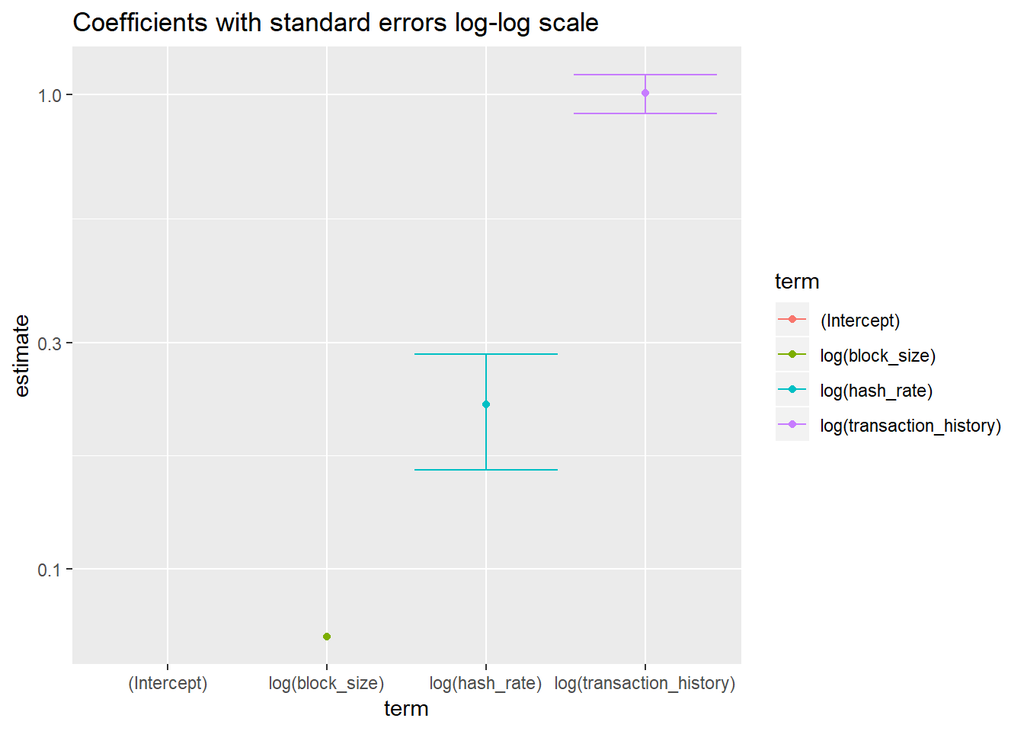

```r
confint_plot +
  scale_y_log10() +
  ggtitle("Coefficients with standard errors log-log scale") +
  scale_x_discrete()
```

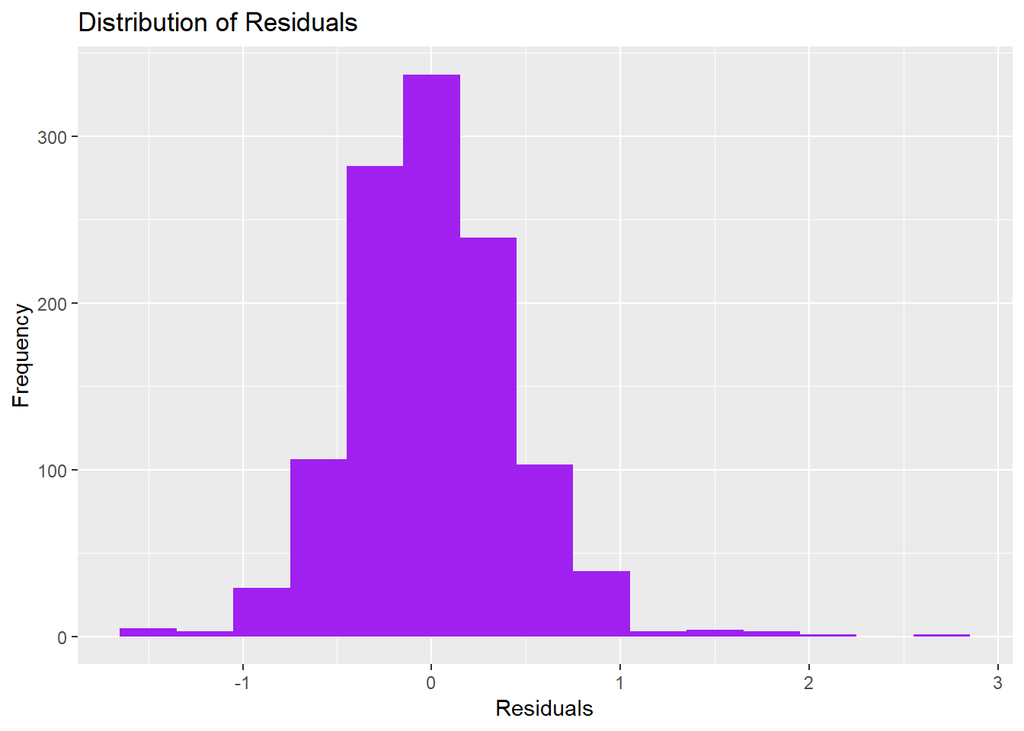

```r
some_plot_2 <- ggplot(data = augmented_reg_obj, aes(.resid)) +
  geom_histogram(binwidth = .3, fill = "purple") +
  labs(x="Residuals", y="Frequency") +
  ggtitle("Distribution of Residuals")



some_plot_2
```

The majority of the residuals are distributed between -1 and 1 peaking at zero. This distribution is similar to the laplace distribution.

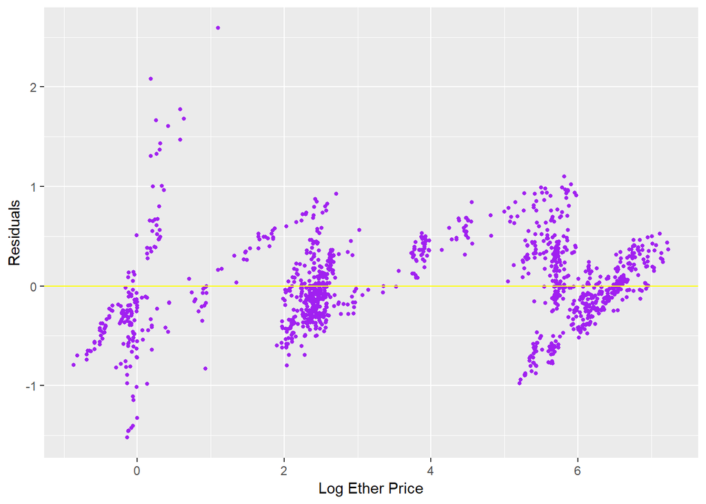

```r
some_plot_3 <- ggplot(augmented_reg_obj, aes(log.price., .resid)) +
  geom_point(color = "purple", size = 1) +
  geom_hline(color = "yellow", yintercept = 0)

some_plot_3 +
  labs(x="Log Ether Price", y="Residuals")
```

The Residuals plotted against Ether Price suggest there is possible non-normality in the distribution of the errors.

## d. and e.) Ridge and Lasso Regressions

```r
library(glmnet)
```

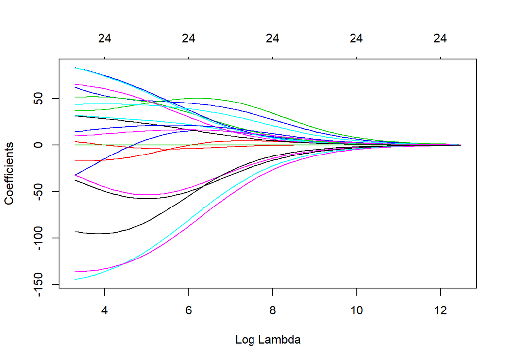

```r
library(caret)


set.seed(385)


train_df <- ether_df %>% sample_frac(0.75)
test_df <- ether_df %>% setdiff(train_df)

train_df <- train_df[, -9, drop=FALSE]

test_df <- test_df[, -9, drop=FALSE]

covariates_train <- model.matrix(price~. , data = train_df)[, c(-1, -9), drop=FALSE]

covariates_test <- model.matrix(price~. , data=test_df)[, c(-1, -9), drop=FALSE]
response_train <- as.numeric(unlist(train_df[[1]]))
response_test <- as.numeric((unlist(test_df[[1]])))

grid <- 10^seq(5, -5, length.out = 100)

ridge_model <- glmnet(covariates_train, response_train, alpha = 0, family ="gaussian")

plot.glmnet(ridge_model, xvar = "lambda")
```

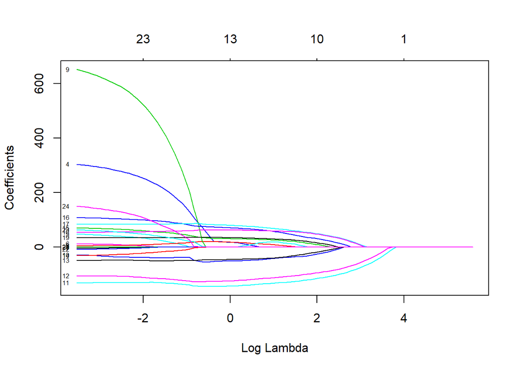

```r
lasso_model <- glmnet(covariates_train, response_train, alpha = 1,  family = "gaussian")


plot.glmnet(lasso_model, xvar = "lambda", label = "true")
```

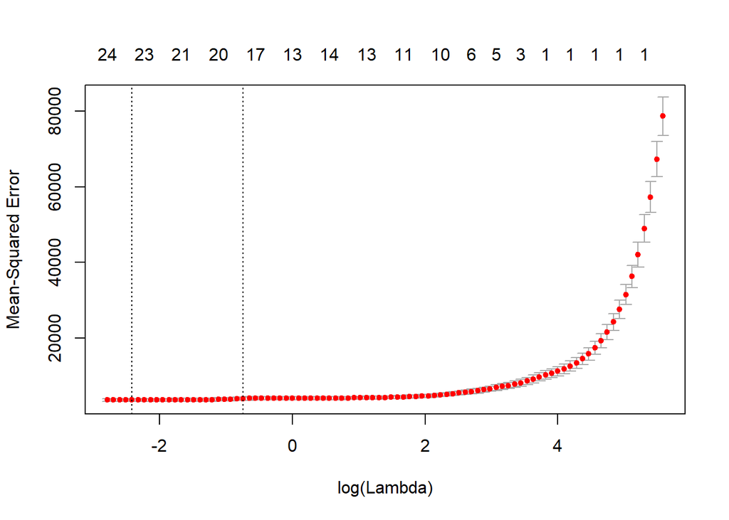

```r
set.seed(385)

cv_lasso <- cv.glmnet(covariates_train, train_df$price, alpha=1)


plot(cv_lasso)
```

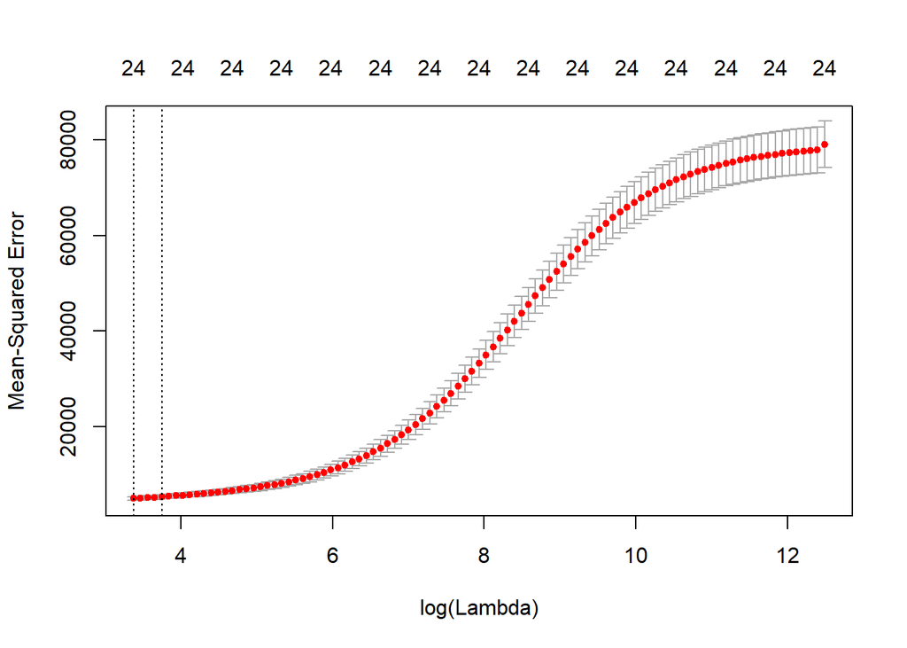

```r
set.seed(385)
cv_ridge <- cv.glmnet(covariates_train, train_df$price, alpha=0)

plot(cv_ridge)
```

```r
best_lambda_ridge <- cv_ridge$lambda.1se

best_lambda_lasso <- cv_lasso$lambda.1se

print(best_lambda_ridge)
```

```
## [1] 42.37694
```

```r
print(best_lambda_lasso)
```

```
## [1] 0.4760304
```

I elect to pick a lambda within one standard deviation as a way to avoid overfitting the model to the training data and performing poorly on the test data.

```r
ridge_coefficients <- coef.glmnet(cv_ridge, newx = covariates_train,  s = best_lambda_ridge)



lasso_coef <- coef.glmnet(cv_lasso, newx = covariates_train, s = best_lambda_lasso)

print(lasso_coef)
```

```
## 25 x 1 sparse Matrix of class "dgCMatrix"
##                                  1
## (Intercept)           2.882101e+03
## transaction_history   6.599955e-04
## block_size            2.559935e-03
## hash_rate             .
## day.L                 8.962718e+01
## day.Q                 .
## day.C                -8.216175e-02
## day^4                 .
## day^6                 1.896173e+01
## month.L               9.227411e+01
## month.Q              -5.154748e+01
## month.C              -1.445795e+02
## month^4              -1.289776e+02
## month^5              -4.927177e+01
## month^6              -2.458906e+00
## month^7               3.694791e+01
## month^8               7.628915e+01
## month^9               8.563579e+01
## month^10              6.134652e+01
## month^11              3.448089e+01
## date_utc             -1.694333e-01
## unix_time_stamp      -3.069279e-18
## log_10_trans_history  1.028775e-01
## log_10_block_size     1.082954e+01
## log_10_hash_rate      .
```

```r
print(ridge_coefficients)
```

```
## 25 x 1 sparse Matrix of class "dgCMatrix"
##                                  1
## (Intercept)          -3.777525e+02
## transaction_history   2.780783e-04
## block_size            5.086334e-03
## hash_rate             6.613319e-05
## day.L                 5.573705e+01
## day.Q                 3.034738e+01
## day.C                -4.081465e+01
## day^4                -4.572158e+01
## day^6                 1.459450e+00
## month.L               3.717301e+01
## month.Q              -2.090293e+01
## month.C              -1.399952e+02
## month^4              -1.349912e+02
## month^5              -9.532313e+01
## month^6              -1.702990e+01
## month^7               5.187222e+01
## month^8               7.800601e+01
## month^9               7.756617e+01
## month^10              6.262248e+01
## month^11              2.935246e+01
## date_utc              4.473379e-03
## unix_time_stamp       6.320744e-08
## log_10_trans_history  1.661339e+01
## log_10_block_size     4.393941e+01
## log_10_hash_rate      1.111034e+01
```

```r
lasso_test_pred = predict.glmnet(lasso_model, newx = covariates_test, s=best_lambda_lasso)

ridge_test_pred = predict.glmnet(ridge_model, newx = covariates_test, s=best_lambda_ridge)

lasso_mse <- mean((response_test - lasso_test_pred) ^ 2)

ridge_mse <- mean((response_test - ridge_test_pred) ^ 2)
```

## f.) Regression trees

```r
library(tree)
set.seed(385)

ether_tree <- tree(price~., data = train_df)
cv_tree <- cv.tree(ether_tree, K=10 )
```

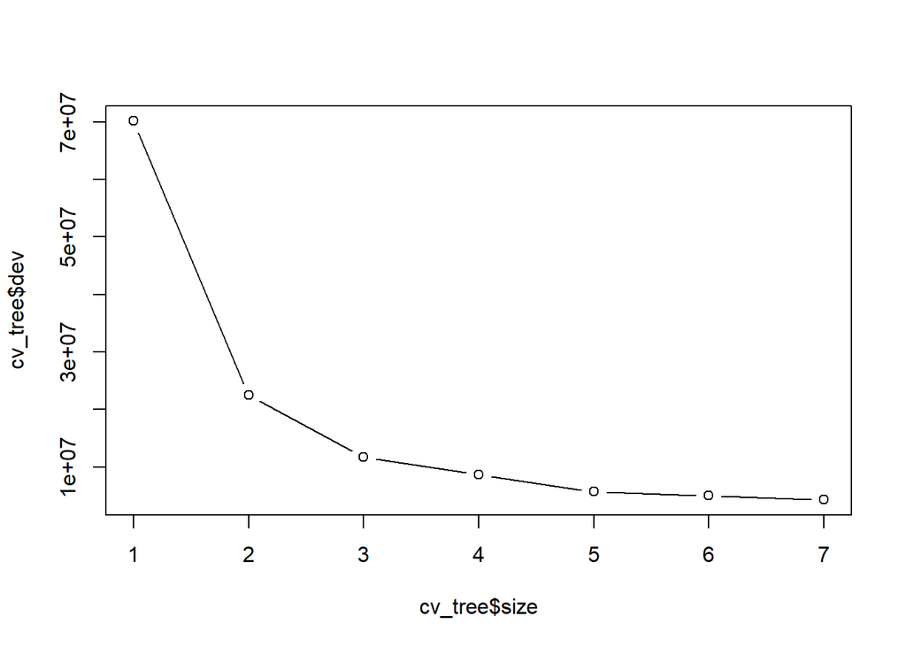

```r
plot(cv_tree$size, cv_tree$dev, type = 'b')
```

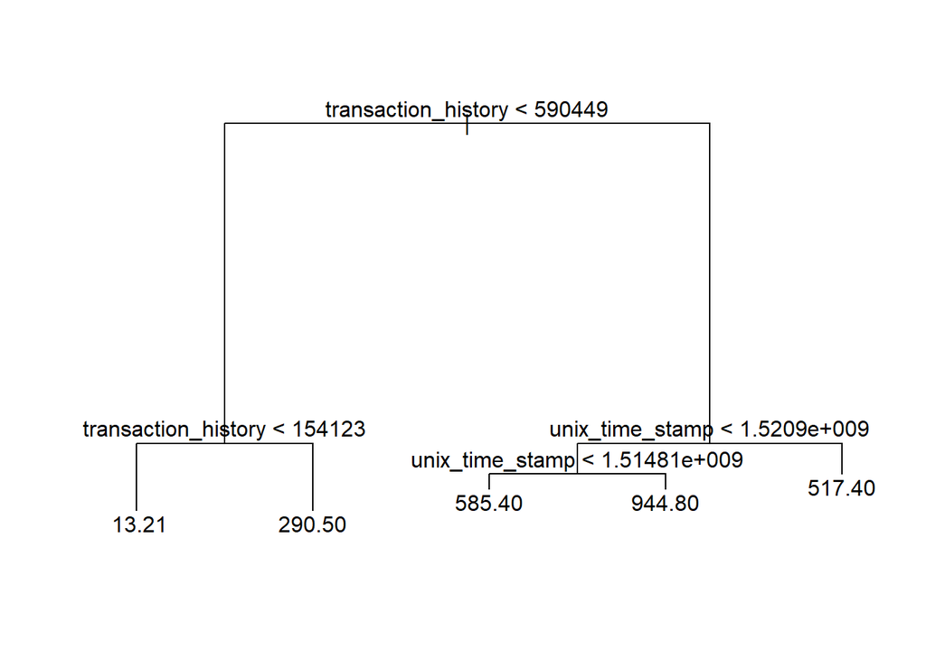

```r
pruned_tree_df <- prune.tree(ether_tree, best = 5)
plot(pruned_tree_df)
text(pruned_tree_df, pretty = 0)
```

```r
treee_fit = predict(pruned_tree_df, newdata = test_df)
single_tree_fit <- mean((response_test - treee_fit) ^ 2)

single_tree_fit
```

```
## [1] 7065.163
```

The pruned regression tree contains a total of five terminal nodes each displaying the average prediction based on those splits in the tree. The splits function to partition space into mutually exclusive regions.

The $MSE$ of the bootstrapped trees is a performance upgrade over the results from the previous performance of the single regression tree trained on the training data. This is not completely surprising as we would expect the model to perform better on our training data and to underperform on the test data. Surprisingly though I was able to get an $MSE$ that was significanctly better accross multiple seeds and fitting trees which is promising, for future reports. Of course there is a trade-off in that we don’t want our model to overfit the training data and not perform well on the test set.

```r
set.seed(385)

new_train_ether <- ether_df[,  -9, drop=FALSE] %>%
  sample_frac(0.7)

new_test_ether <- ether_df[,  -9, drop=FALSE] %>%
  setdiff(new_train_ether)

bagged.ether <- randomForest(price ~ ., data = new_train_ether,
                             ntree=400, mtry=4, importance=TRUE)
bagged.ether
```

```
##
## Call:
##  randomForest(formula = price ~ ., data = new_train_ether, ntree = 400,      mtry = 4, importance = TRUE)
##                Type of random forest: regression
##                      Number of trees: 400
## No. of variables tried at each split: 4
##
##           Mean of squared residuals: 841.0136
##                     % Var explained: 98.92
```

# g.) Bagging

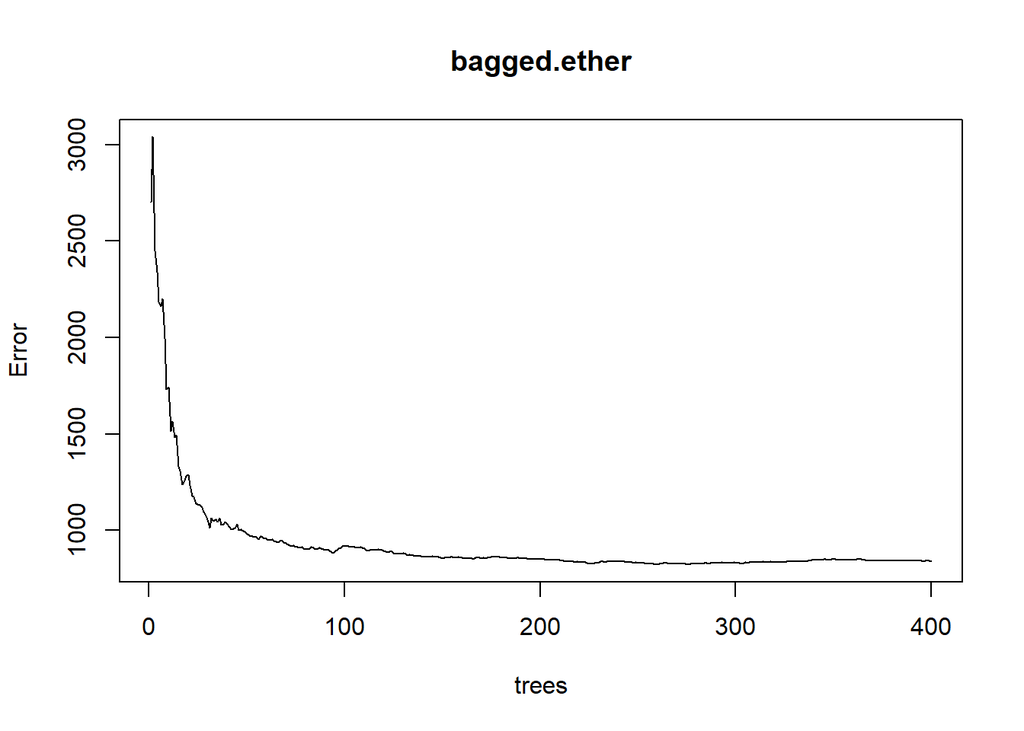

```r
plot(bagged.ether)
```

The Errors start to level off as trees start approaching the 50 to 75 tree range. Increasing the number of trees does not impact the error rate that much, as the number of trees gets large.

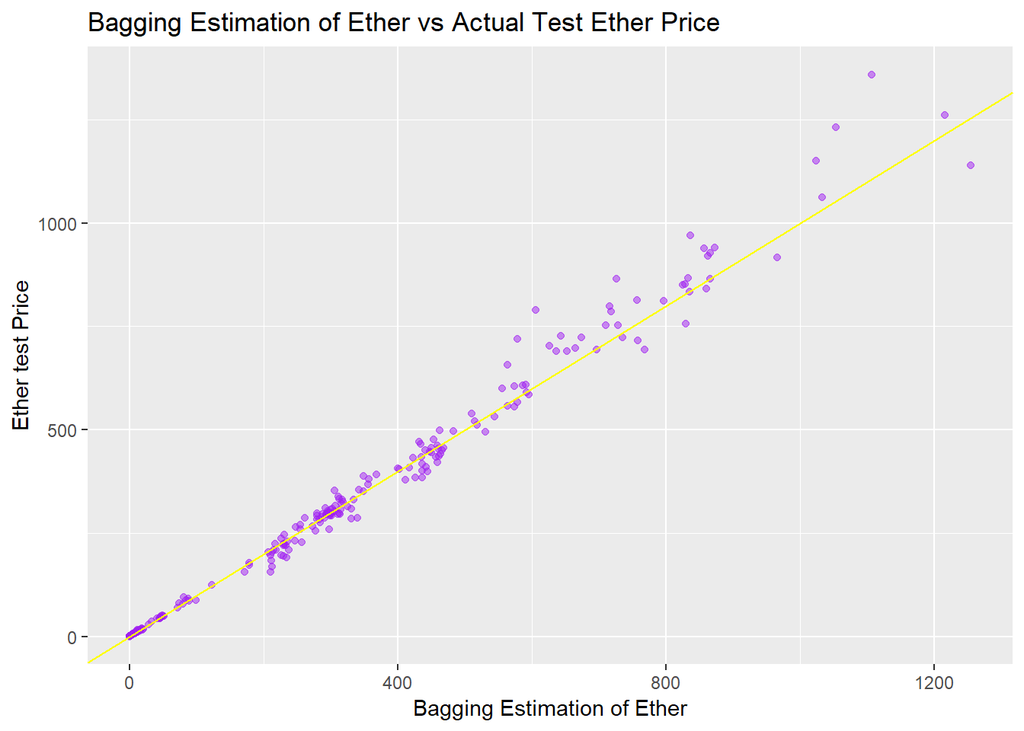

```r
yhat_bagged <- predict(bagged.ether, newdata = new_test_ether)

ggplot() + geom_point(aes(x = yhat_bagged, y = price), data = new_test_ether, color = "purple", alpha = 0.50) + geom_abline(color = "yellow") +
  labs(x="Bagging Estimation of Ether", y="Ether test Price", title="Bagging Estimation of Ether vs Actual Test Ether Price")
```

The Bagging estimation of Ether Price presents some of the best predictions on the test set of all methods. However the fit is not as tight as Ether Price increases. In addition it is an improvement over the bootstrapped version of the trees from my previous report.

```r
bagging_mse <- round(mean((new_test_ether$price - yhat_bagged)^2), 2)
bagging_mse
```

```
## [1] 1023.55
```

```r
lasso_mse
```

```
## [1] 4856.384
```

```r
ridge_mse
```

```
## [1] 6754.554
```

```r
importance(bagged.ether)
```

```
##                        %IncMSE IncNodePurity
## transaction_history  17.519438    19516183.8
## block_size            5.720252     1223755.0
## hash_rate            11.547024     4297789.2
## day                   3.506249      397732.7
## month                 9.956650      304200.3
## date_utc             17.289614     7381109.0
## unix_time_stamp      13.560347     6296278.4
## log_10_trans_history 16.717946    18179167.2
## log_10_block_size     6.512033      905932.8
## log_10_hash_rate     10.455341     5128741.0
```

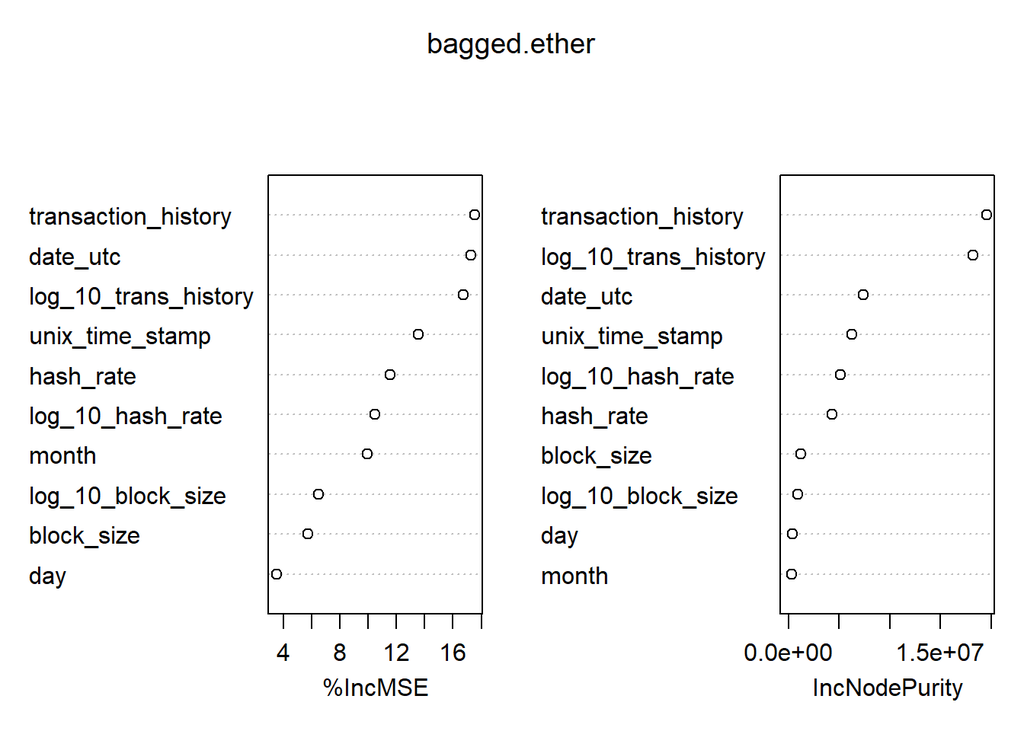

```r
varImpPlot(bagged.ether)
```

In terms of important variables for the bagging model date, unix time stamp, log_10_transaction history, and transaction history have the largest increased percentage in the mean squared errors. It is a more robust measure of error versus the IncNodePurity.

# h.) Random Forest

```r
set.seed(385)

ether_forest <- randomForest(price ~ ., data = new_train_ether,
                             mtry = 10,
                             importance = TRUE,
                             do.trace = 100)
```

```
##      |      Out-of-bag   |
## Tree |      MSE  %Var(y) |
##  100 |    898.8     1.15 |
##  200 |    923.3     1.18 |
##  300 |    922.8     1.18 |
##  400 |    926.3     1.18 |
##  500 |    922.2     1.18 |
```

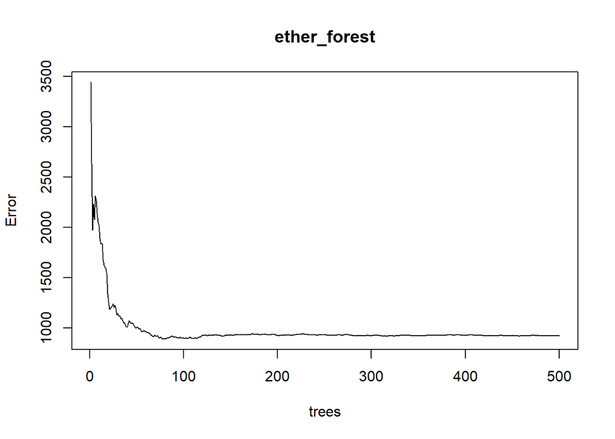

```r
plot(ether_forest)
```

Error mostly flat lines as number of trees approaches 50.

```r
y_hat_rf <- predict(ether_forest, newdata = new_test_ether)
```

```r
# Set mtry using hyperparamter tuning

oob_err <- double(10)
test_err <- double(10)

#mtry is no of Variables randomly chosen at each split
for(mtry in 1:10)
{
  rf_ether <- randomForest(price ~ . , data = new_train_ether, mtry=mtry, ntree=400)
  oob_err[mtry] <- rf_ether$mse[400] #Error of all Trees fitted on training

  pred <- predict(rf_ether, new_test_ether) #Predictions on Test Set for each Tree
  test_err[mtry] <- with(new_test_ether, mean( (price - pred)^2)) # "Test" Mean Squared Error

  print(mtry)

}
```

```
## [1] 1
## [1] 2
## [1] 3
## [1] 4
## [1] 5
## [1] 6
## [1] 7
## [1] 8
## [1] 9
## [1] 10
```

```r
round(test_err, 2)
```

```
##  [1] 1952.66 1261.91 1153.59 1036.57  985.34  980.64  985.20  977.75
##  [9]  989.61  958.63
```

```r
round(oob_err, 2)
```

```
##  [1] 1540.82  976.01  905.66  874.61  811.87  824.64  846.62  920.40
##  [9]  925.14  889.12
```

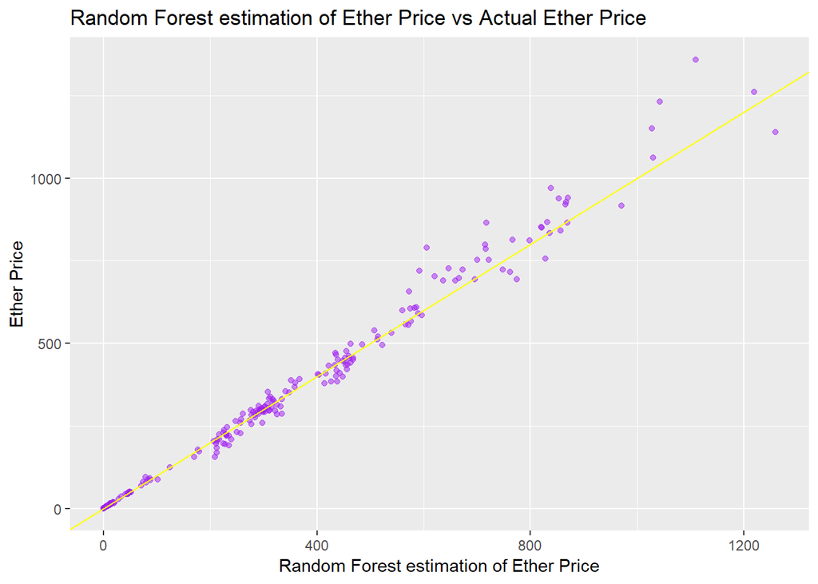

```r
rf.opt <- randomForest(price ~ ., data = new_train_ether, n_tree = 400, mtry = 4)

y_hat_rf_opt <- predict(rf.opt, newdata = new_test_ether)

ggplot() + geom_point(aes(x = y_hat_rf_opt, y = new_test_ether$price), color = "purple", alpha=0.5) + geom_abline(color = "yellow") +
  labs(x="Random Forest estimation of Ether Price", y="Ether Price", title = "Random Forest estimation of Ether Price vs Actual Ether Price")
```

The residuals increase as Ether Price increases similar to other tree based methods, but has one of the best fits of all the tree based models.

```r
mse_random_forest <- round(mean((new_test_ether$price - y_hat_rf_opt)^2))
lasso_mse
```

```
## [1] 4856.384
```

```r
ridge_mse
```

```
## [1] 6754.554
```

```r
bagging_mse
```

```
## [1] 1023.55
```

```r
mse_random_forest
```

```
## [1] 1033
```

Random forest fits Ether Price really well better than any other models used so far, except bagging.

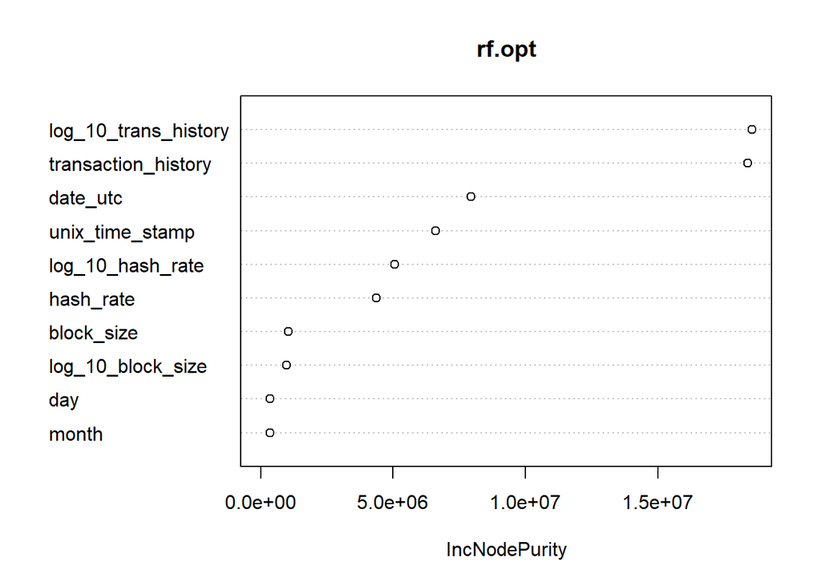

```r
varImpPlot(rf.opt)
```

Like the other tree based models random forest emphasizes the importance of transaction history as well as time.

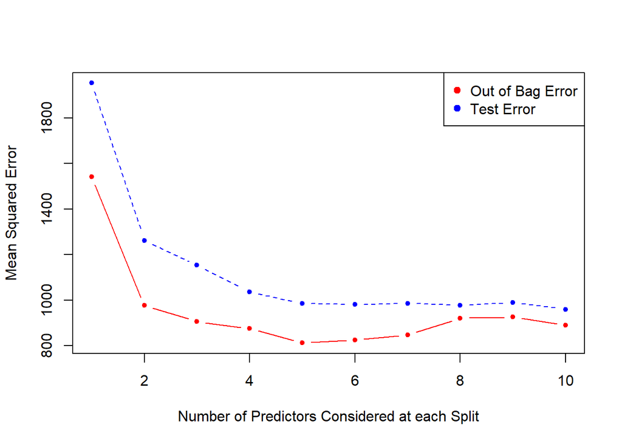

```r
matplot(1:mtry , cbind(oob_err,test_err), pch=20 , col=c("red","blue"),type="b",ylab="Mean Squared Error",xlab="Number of Predictors Considered at each Split")
legend("topright",legend=c("Out of Bag Error","Test Error"),pch=19, col=c("red","blue"))
```

# i.) Boosting

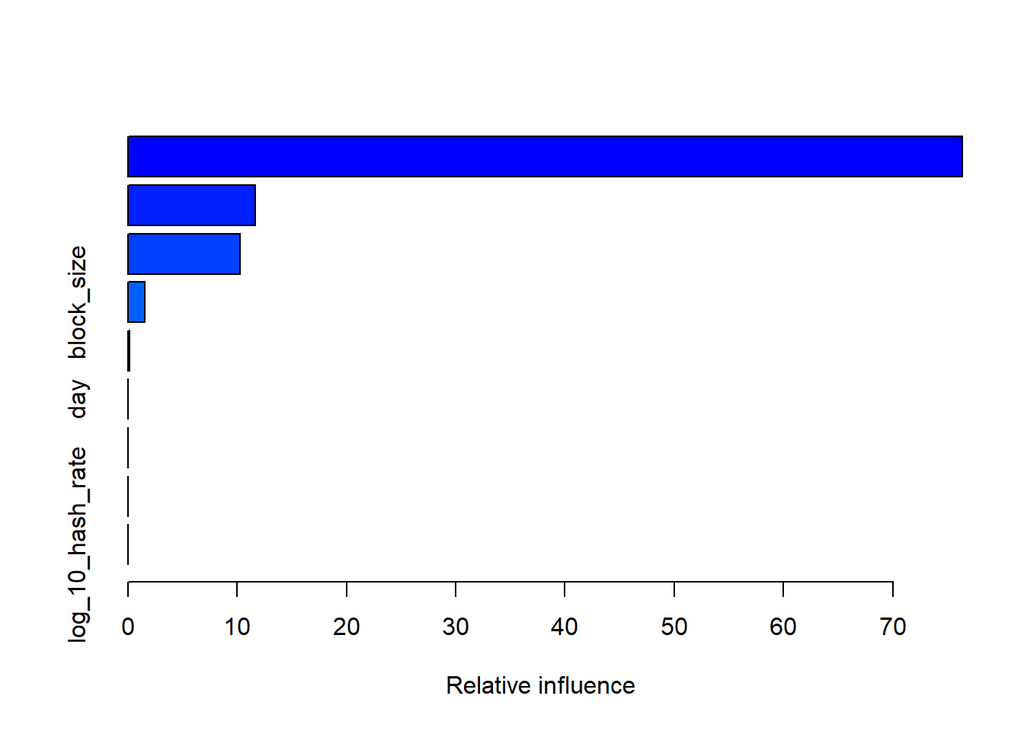

```
##                                       var     rel.inf
## transaction_history   transaction_history 76.36388177
## unix_time_stamp           unix_time_stamp 11.67068882
## hash_rate                       hash_rate 10.23334924
## block_size                     block_size  1.54143898
## month                               month  0.16852778
## day                                   day  0.02211341
## log_10_trans_history log_10_trans_history  0.00000000
## log_10_block_size       log_10_block_size  0.00000000
## log_10_hash_rate         log_10_hash_rate  0.00000000
```

```r
set.seed(385)
boosting_ether <- gbm(price ~ . -date_utc,
                      data = new_train_ether,
                      distribution = "gaussian",
                      n.trees = 5000,
                      interaction.depth = 4)
summary(boosting_ether)
```

Transaction history, Unix time stamp, and hash rate are all displayed as important variables according to the importance matrix. Transaction history carries the largest relative importance of all the variables at a value of 76.36 pecent. While unix time stamp has an importance of 11.67 percent which is not very significant. The only other variable containing a significant amount of importance is network hash rate.

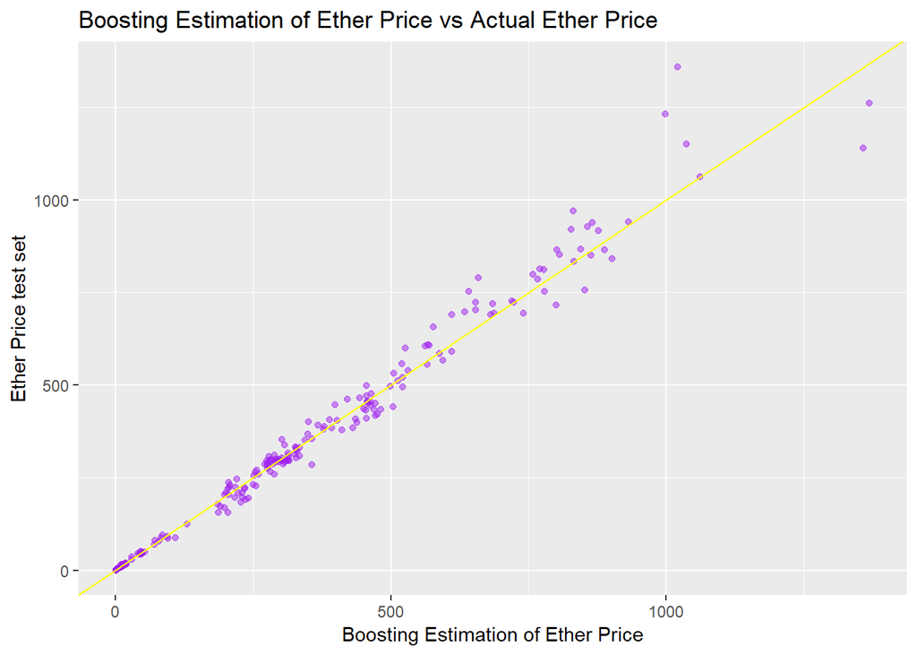

```r
yhat_boost <- predict(boosting_ether, newdata = new_test_ether, n.trees = 5000)

ggplot() + geom_point(aes(x = yhat_boost, y = new_test_ether$price), color = "purple", alpha=0.5) + geom_abline(color = "yellow") +
  labs(x="Boosting Estimation of Ether Price", y="Ether Price test set", title = "Boosting Estimation of Ether Price vs Actual Ether Price")
```

Boosting is a relatively viable modeling technique, for predicting ether price given the fit above.

```r
boosting_mse <- mean((new_test_ether$price - yhat_boost)^2)
boosting_mse
```

```
## [1] 1299.219
```

```r
lasso_mse
```

```
## [1] 4856.384
```

```r
ridge_mse
```

```
## [1] 6754.554
```

```r
bagging_mse
```

```
## [1] 1023.55
```

## j.) XGboost

```r
library(xgboost)
```

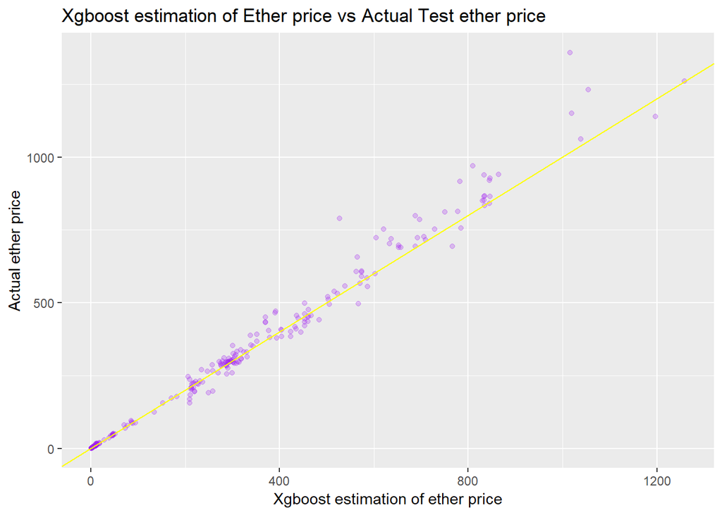

```r
f <- price ~ transaction_history + block_size + hash_rate + day + month + unix_time_stamp + log_10_trans_history + log_10_block_size + log_10_hash_rate

X_training <- model.matrix(f, data = new_train_ether)

Y_training <- as.matrix(new_train_ether$price)

d_train <- xgb.DMatrix(data = X_training, label = Y_training)

X_test <- model.matrix(f, data = new_test_ether)

set.seed(385)
ether.xgb = xgboost(data=d_train,
                     max_depth=5,
                     eta = 0.1,
                     nrounds=40,
                     lambda=0,
                     print_every_n = 10,
                     objective="reg:linear")
yhat_xgboost <- predict(ether.xgb, newdata = X_test)

ggplot() + geom_point(aes(x = yhat_xgboost, y = price), data = new_test_ether, color = "purple", alpha = 0.25) +
  geom_abline(color = "yellow") +
  labs(x="Xgboost estimation of ether price", y="Actual ether price", title = "Xgboost estimation of Ether price vs Actual Test ether price")
```

The xgboosted model performs relatively strong, but like other tree based models the fit is not as good as Ether Price increases.

```r
 xg_boosted_mse <- mean((new_test_ether$price - yhat_xgboost)^2)
 lasso_mse
```

```
## [1] 4856.384
```

```r
 ridge_mse
```

```
## [1] 6754.554
```

```r
 bagging_mse
```

```
## [1] 1023.55
```

```r
 mse_random_forest
```

```
## [1] 1033
```

```r
 boosting_mse
```

```
## [1] 1299.219
```

```r
 xg_boosted_mse
```

```
## [1] 1415.984
```

An MSE of 1415.984 is returned by the xgboosted model is respectable in comparison to boosting and the other tree-based methods, but does not perform aswell as Random Forest or gradient boosting.

```r
 importance_xgb <- xgb.importance(colnames(X_training), model = ether.xgb)

 importance_xgb
```

```
##                 Feature         Gain        Cover    Frequency
##  1: transaction_history 8.414218e-01 0.3083559341 0.2126957955
##  2:     unix_time_stamp 6.404693e-02 0.2829776529 0.3116240725
##  3:             month^4 3.466218e-02 0.0437063581 0.0403957131
##  4:           hash_rate 2.840472e-02 0.2473400665 0.3042044518
##  5:          block_size 1.864543e-02 0.0724655467 0.1071723001
##  6:               day.L 1.190196e-02 0.0041479009 0.0024732069
##  7:               day^4 3.813924e-04 0.0018162406 0.0016488046
##  8:               day.C 2.696592e-04 0.0176285788 0.0065952185
##  9:             month.C 2.021376e-04 0.0013499086 0.0016488046
## 10:             month^9 4.538439e-05 0.0170395278 0.0090684254
## 11:             month^8 1.818364e-05 0.0007485857 0.0008244023
## 12:            month^11 2.222427e-07 0.0024236995 0.0016488046
```

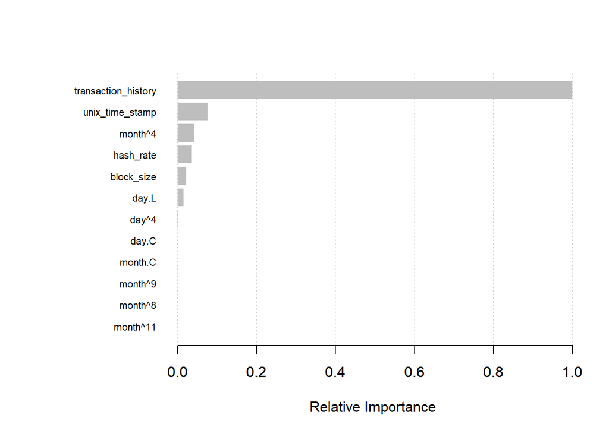

```r
 xgb.plot.importance(importance_matrix = importance_xgb, rel_to_first = TRUE, xlab="Relative Importance")
```

Transaction history displays an overwhelming level of relative importance for the xgboosted model as shown above. With time or unix time stamp being the only other important variable.

```r
library(caret)

f <- price ~ transaction_history + block_size + hash_rate + day + month + unix_time_stamp + log_10_trans_history + log_10_block_size + log_10_hash_rate

X_training <- model.matrix(f, data = new_train_ether)

Y_training <- as.matrix(new_train_ether$price)

d_train <- xgb.DMatrix(data = X_training, label = Y_training)

X_test <- model.matrix(f, data = new_test_ether)

params_xgboost <- list(nrounds = seq(40, 250, 5),
                     max_depth = 4,
                     eta = seq(2, 30,5)/60,
                     gamma = 1,
                     colsample_bytree = 1,
                     min_child_weight = 9,
                     subsample =  1.0
                     )

hyper_grid_xgboost <- expand.grid(params_xgboost)
xgb_control <- trainControl(method="cv",
                            number = 3)
set.seed(385)
xgboost_tuned <- train(price~.,
                        data=new_train_ether,
                        trControl=xgb_control,
                        tuneGrid=hyper_grid_xgboost,
                        lambda=0,
                        method="xgbTree")
xgboost_tuned$bestTune
```

```
##     nrounds max_depth eta gamma colsample_bytree min_child_weight
## 124     225         4 0.2     1                1                9
##     subsample
## 124         1
```

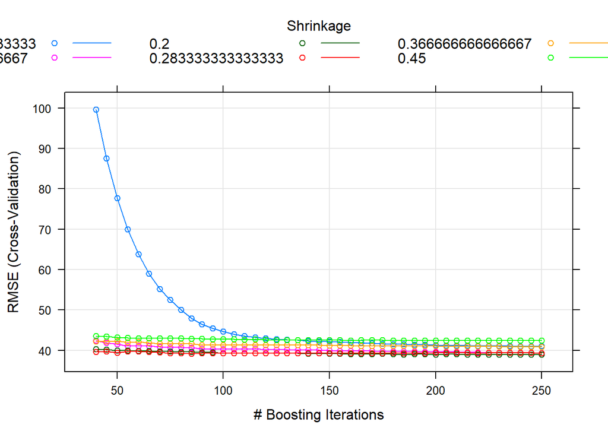

```r
plot(xgboost_tuned)
```

```r
tuned.xgb <- xgb.train(params = xgboost_tuned$bestTune,
                       data = d_train,
                       nrounds = 225)
yhat_xgboost_tuned <- predict(tuned.xgb, X_test)
tuned_xgboost_mse <- mean((yhat_xgboost_tuned - new_test_ether$price)^2)
tuned_xgboost_mse
```

```
## [1] 1360.191
```

```r
xg_boosted_mse
```

```
## [1] 1415.984
```

The hyper-paramater tuned model only offers a marginal decrease in the $MSE$ aproximately 56.

```r
gbm.grid <- expand.grid(interaction.depth = c(1, 4, 5, 9),
                        n.trees = (1:100)*50,
                        n.minobsinnode = c(10, 20, 25),
                        shrinkage = 0.1)
nrow(gbm.grid)
```

```
## [1] 1200
```

```r
fit.control <- trainControl(method = "repeatedcv",
                            number = 5,
                            repeats = 5)

set.seed(385)

gbm.tuned <- train(price ~ . -date_utc,
                   data = new_train_ether,
                   method = "gbm",
                   trControl = fit.control,
                   verbose = FALSE,
                   tuneGrid = gbm.grid)

gbm.tuned
```

[output not shown]

[output cut: 2362 more lines]

```
##   17.15093
##   17.14949
##   17.14885
##   17.13928
##   17.13947
##   17.14446
##   17.13923
##   17.14271
##   17.14091
##   17.14269
##
## Tuning parameter 'shrinkage' was held constant at a value of 0.1
## RMSE was used to select the optimal model using the smallest value.
## The final values used for the model were n.trees = 2750,
##  interaction.depth = 9, shrinkage = 0.1 and n.minobsinnode = 10.
```

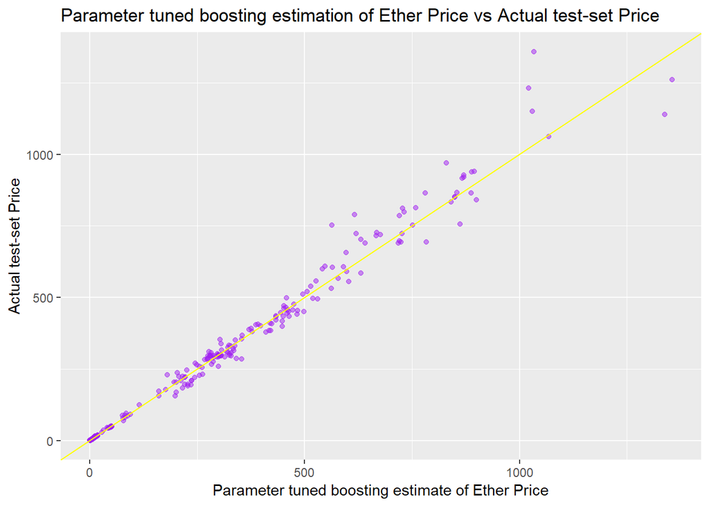

```r
y_hat_tuned <- predict.train(gbm.tuned, newdata = new_test_ether, type ='raw')

ggplot()+ geom_point(aes(x = y_hat_tuned, y = new_test_ether$price), color = "purple", alpha = 0.50) +
  geom_abline(color = "yellow") +
  labs(x="Parameter tuned boosting estimate of Ether Price", y="Actual test-set Price", title = "Parameter tuned boosting estimation of Ether Price vs Actual test-set Price")
```

The Parameter boosted model gives a relatively tight fit around the ideal fit line. With larger residuals resulting as the price increases.

```r
mse_tuned <- round(mean((new_test_ether$price - y_hat_tuned)^2), 2)
mse_tuned
```

```
## [1] 1347.41
```

```r
mse_random_forest
```

```
## [1] 1033
```

```r
bagging_mse
```

```
## [1] 1023.55
```

```r
lasso_mse
```

```
## [1] 4856.384
```

```r
ridge_mse
```

```
## [1] 6754.554
```

```r
boosting_mse
```

```
## [1] 1299.219
```

```r
xg_boosted_mse
```

```
## [1] 1415.984
```

```r
with_2_standard_errs <- oneSE(gbm.tuned$results, metric = "RMSE", num = 5, maximize = FALSE)
gbm.tuned$results[with_2_standard_errs, 1:6]
```

```
##     shrinkage interaction.depth n.minobsinnode n.trees     RMSE  Rsquared
## 214       0.1                 5             20     700 38.17914 0.9817438
```

These would be the ideal hyperparameter values to fit a gradient boosted model to avoid overfitting based on the one standard error rule of thumb.

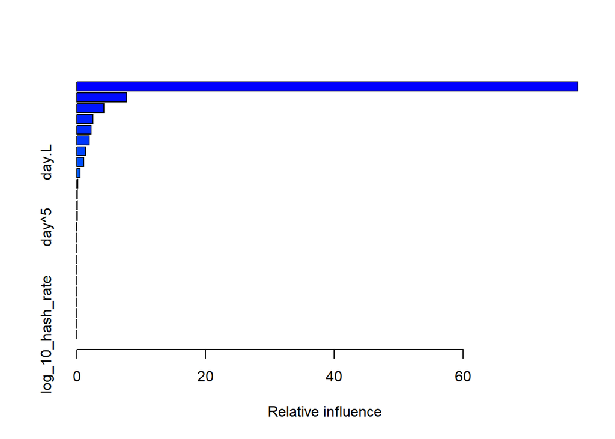

```
##                                       var      rel.inf
## transaction_history   transaction_history 77.854912023
## unix_time_stamp           unix_time_stamp  7.730324978
## hash_rate                       hash_rate  4.179951037
## block_size                     block_size  2.495473244
## month^7                           month^7  2.238889079
## month^4                           month^4  1.952791795
## month^8                           month^8  1.362624481
## day.L                               day.L  1.089253804
## month^5                           month^5  0.536768946
## day^4                               day^4  0.178614772
## day.C                               day.C  0.076595887
## month^9                           month^9  0.073451610
## month^6                           month^6  0.065893491
## day^5                               day^5  0.039217726
## month^10                         month^10  0.035386582
## month.C                           month.C  0.027721130
## month.L                           month.L  0.024060953
## month.Q                           month.Q  0.019392069
## day.Q                               day.Q  0.012090959
## day^6                               day^6  0.003336322
## month^11                         month^11  0.003249112
## log_10_trans_history log_10_trans_history  0.000000000
## log_10_block_size       log_10_block_size  0.000000000
## log_10_hash_rate         log_10_hash_rate  0.000000000
```

```r
summary(gbm.tuned)
```

Similiar to previous importance plots transaction history has the largest relative influence on ether price. Which makes some intuitive sense as investors might believe in the technology more as it usage increases. None of the other variables show much of a relative influence.